# 3. 神经网络入门

Deep Learning I

3. 神经网络入门

WU Xiaokun 吴晓堃

xkun.wu [at] gmail

2021/03/29

## 本章内容

神经网络剖析。 IMDB电影评论分类：二分类问题。 路透社新闻分类：多分类问题。 波士顿预测房价：标量回归问题。 实践：三类基本问题。

**重点**：层、神经网络拓扑、监督学习的三类基本使用场景；

**难点**：监督学习中三类基本问题的Keras基础实现。

## 学习目标

- 理解神经网络的基本构成单元（层）及其拓扑结构；
- 理解监督学习的三类基本使用场景：二分类问题、多分类问题和标量回归问题；
- 掌握监督学习中三类基本问题的Keras基础实现。

## 概念

### 层

层是数据处理单元，将输入张量转换为输出张量。

### 模型

层构成的网络（有向无环图）；网络的拓扑结构定义了一个假设空间。 例如：密集连接网络假设输入特征中没有特定结构。

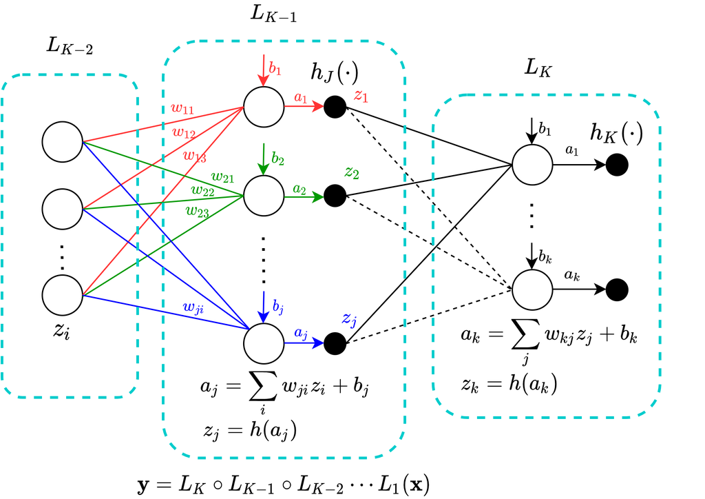

## 监督学习的三大基本问题

### 二分类

- 概率输出：`sigmoid` 激活；
- 损失函数：二元交叉熵（`binary_crossentropy`）。

### 多分类

- 概率输出：`softmax` 激活；
- 损失函数：分类交叉熵（`categorical_crossentropy`）。

### 回归

- 标量输出：无激活；
- 损失函数：均方误差（MSE，mean squared error）。

## 二分类问题

```python
from keras import models
from keras import layers

model = models.Sequential()
model.add(layers.Dense(32, activation='relu', input_shape=(num_input_features,)))
model.add(layers.Dense(32, activation='relu'))
model.add(layers.Dense(1, activation='sigmoid'))

model.compile(optimizer='rmsprop', loss='binary_crossentropy')
```

## 单标签多分类问题

```python
from keras import models
from keras import layers

model = models.Sequential()
model.add(layers.Dense(32, activation='relu', input_shape=(num_input_features,)))
model.add(layers.Dense(32, activation='relu'))
model.add(layers.Dense(num_classes, activation='softmax'))

model.compile(optimizer='rmsprop', loss='categorical_crossentropy')
```

## 多标签多分类问题

```python
from keras import models
from keras import layers

model = models.Sequential()
model.add(layers.Dense(32, activation='relu', input_shape=(num_input_features,)))
model.add(layers.Dense(32, activation='relu'))
model.add(layers.Dense(num_classes, activation='sigmoid'))

model.compile(optimizer='rmsprop', loss='binary_crossentropy')
```

## 过拟合与欠拟合：理想曲线

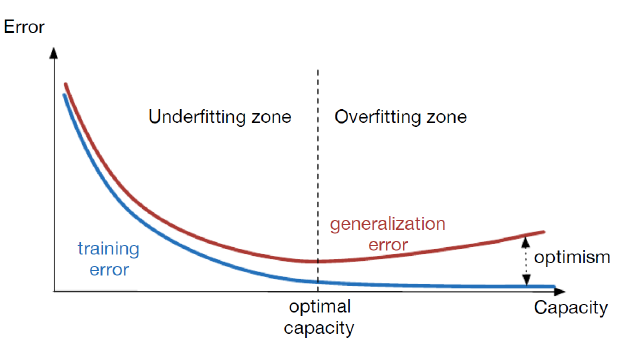

## 过拟合与欠拟合：实际曲线

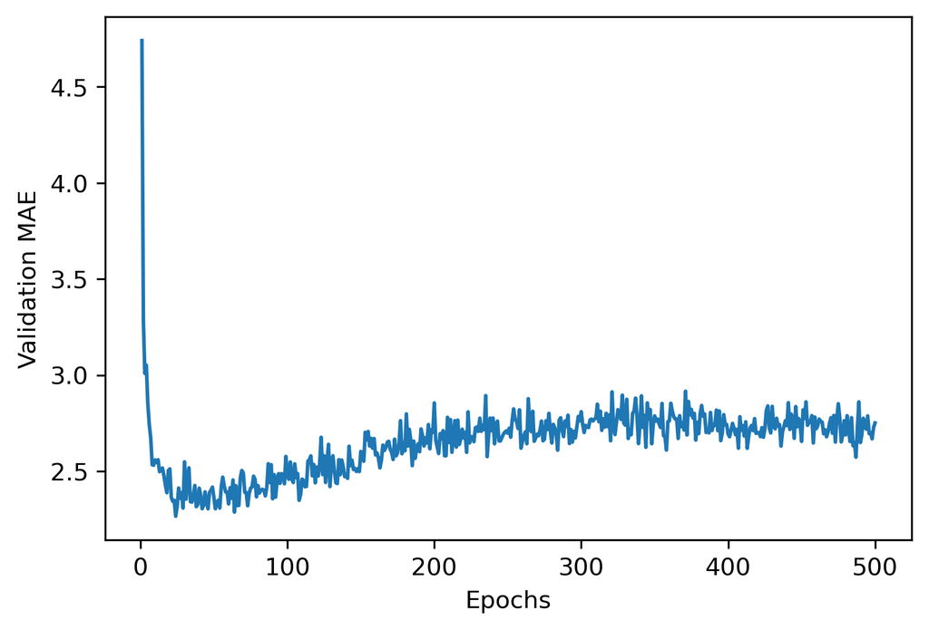

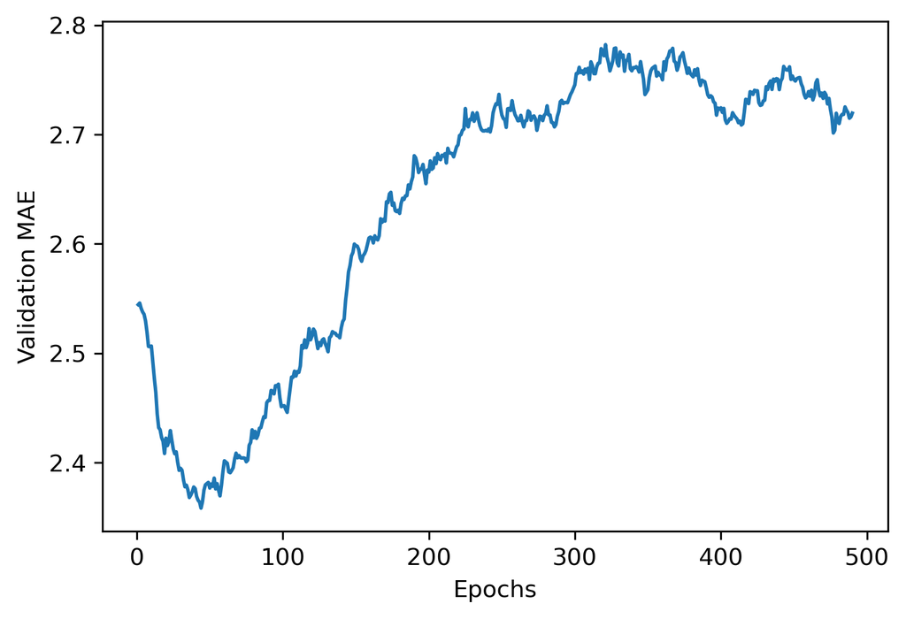

## K-fold 交叉验证

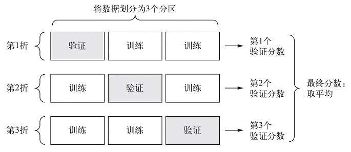

## 回归问题

```python
from keras import models
from keras import layers

model = models.Sequential()
model.add(layers.Dense(32, activation='relu', input_shape=(num_input_features,)))
model.add(layers.Dense(32, activation='relu'))
model.add(layers.Dense(num_values))

model.compile(optimizer='rmsprop', loss='mse')
```